# Risk Factor Analysis

## Outcome Variable

**Outcome Variable:** ever_stunted

## Predictor Variables

**Intervention Variable:** hdlvry

**Adjustment Set:**

- arm
- sex
- W_mage
- meducyrs
- feducyrs
- hhwealth_quart
- W_nrooms
- brthmon
- W_parity
- impsan
- delta_W_mage
- delta_meducyrs
- delta_feducyrs
- delta_hhwealth_quart
- delta_W_nrooms
- delta_brthmon
- delta_W_parity
- delta_impsan

## Stratifying Variables

The analysis was stratified on these variable(s):

- agecat
- studyid
- country

## Data Summary

| agecat | studyid | country | hdlvry | ever_stunted | n_cell | n |
| --- | --- | --- | --- | --- | --- | --- |
| 0-6 months | ki1000108-CMC-V-BCS-2002 | INDIA | 0 | 0 | 284 | 365 |
| 0-6 months | ki1000108-CMC-V-BCS-2002 | INDIA | 0 | 1 | 74 | 365 |
| 0-6 months | ki1000108-CMC-V-BCS-2002 | INDIA | 1 | 0 | 5 | 365 |
| 0-6 months | ki1000108-CMC-V-BCS-2002 | INDIA | 1 | 1 | 2 | 365 |
| 0-6 months | ki1000108-IRC | INDIA | 0 | 0 | 353 | 410 |
| 0-6 months | ki1000108-IRC | INDIA | 0 | 1 | 49 | 410 |
| 0-6 months | ki1000108-IRC | INDIA | 1 | 0 | 7 | 410 |
| 0-6 months | ki1000108-IRC | INDIA | 1 | 1 | 1 | 410 |
| 0-6 months | ki1000109-EE | PAKISTAN | 0 | 0 | 162 | 377 |
| 0-6 months | ki1000109-EE | PAKISTAN | 0 | 1 | 91 | 377 |
| 0-6 months | ki1000109-EE | PAKISTAN | 1 | 0 | 85 | 377 |
| 0-6 months | ki1000109-EE | PAKISTAN | 1 | 1 | 39 | 377 |
| 0-6 months | ki1000304b-SAS-CompFeed | INDIA | 0 | 0 | 113 | 1248 |
| 0-6 months | ki1000304b-SAS-CompFeed | INDIA | 0 | 1 | 53 | 1248 |
| 0-6 months | ki1000304b-SAS-CompFeed | INDIA | 1 | 0 | 774 | 1248 |
| 0-6 months | ki1000304b-SAS-CompFeed | INDIA | 1 | 1 | 308 | 1248 |
| 0-6 months | ki1000304b-SAS-FoodSuppl | INDIA | 0 | 0 | 58 | 416 |
| 0-6 months | ki1000304b-SAS-FoodSuppl | INDIA | 0 | 1 | 23 | 416 |
| 0-6 months | ki1000304b-SAS-FoodSuppl | INDIA | 1 | 0 | 199 | 416 |
| 0-6 months | ki1000304b-SAS-FoodSuppl | INDIA | 1 | 1 | 136 | 416 |
| 0-6 months | ki1017093b-PROVIDE | BANGLADESH | 0 | 0 | 469 | 700 |
| 0-6 months | ki1017093b-PROVIDE | BANGLADESH | 0 | 1 | 50 | 700 |
| 0-6 months | ki1017093b-PROVIDE | BANGLADESH | 1 | 0 | 165 | 700 |
| 0-6 months | ki1017093b-PROVIDE | BANGLADESH | 1 | 1 | 16 | 700 |
| 0-6 months | ki1017093c-NIH-Crypto | BANGLADESH | 0 | 0 | 514 | 758 |
| 0-6 months | ki1017093c-NIH-Crypto | BANGLADESH | 0 | 1 | 76 | 758 |
| 0-6 months | ki1017093c-NIH-Crypto | BANGLADESH | 1 | 0 | 139 | 758 |
| 0-6 months | ki1017093c-NIH-Crypto | BANGLADESH | 1 | 1 | 29 | 758 |
| 0-6 months | ki1066203-TanzaniaChild2 | TANZANIA, UNITED REPUBLIC OF | 0 | 0 | 2091 | 2274 |
| 0-6 months | ki1066203-TanzaniaChild2 | TANZANIA, UNITED REPUBLIC OF | 0 | 1 | 143 | 2274 |

[output cut: 112 more lines]

The following strata were considered:

- agecat: 0-24 months, studyid: ki1000108-CMC-V-BCS-2002, country: INDIA
- agecat: 0-24 months, studyid: ki1000108-IRC, country: INDIA
- agecat: 0-24 months, studyid: ki1000109-EE, country: PAKISTAN
- agecat: 0-24 months, studyid: ki1000304b-SAS-CompFeed, country: INDIA
- agecat: 0-24 months, studyid: ki1000304b-SAS-FoodSuppl, country: INDIA
- agecat: 0-24 months, studyid: ki1017093b-PROVIDE, country: BANGLADESH
- agecat: 0-24 months, studyid: ki1017093c-NIH-Crypto, country: BANGLADESH
- agecat: 0-24 months, studyid: ki1066203-TanzaniaChild2, country: TANZANIA, UNITED REPUBLIC OF
- agecat: 0-24 months, studyid: ki1113344-GMS-Nepal, country: NEPAL
- agecat: 0-24 months, studyid: ki1135781-COHORTS, country: INDIA
- agecat: 0-24 months, studyid: kiGH5241-JiVitA-3, country: BANGLADESH
- agecat: 0-24 months, studyid: kiGH5241-JiVitA-4, country: BANGLADESH
- agecat: 0-6 months, studyid: ki1000108-CMC-V-BCS-2002, country: INDIA
- agecat: 0-6 months, studyid: ki1000108-IRC, country: INDIA
- agecat: 0-6 months, studyid: ki1000109-EE, country: PAKISTAN
- agecat: 0-6 months, studyid: ki1000304b-SAS-CompFeed, country: INDIA
- agecat: 0-6 months, studyid: ki1000304b-SAS-FoodSuppl, country: INDIA
- agecat: 0-6 months, studyid: ki1017093b-PROVIDE, country: BANGLADESH
- agecat: 0-6 months, studyid: ki1017093c-NIH-Crypto, country: BANGLADESH
- agecat: 0-6 months, studyid: ki1066203-TanzaniaChild2, country: TANZANIA, UNITED REPUBLIC OF
- agecat: 0-6 months, studyid: ki1113344-GMS-Nepal, country: NEPAL
- agecat: 0-6 months, studyid: ki1135781-COHORTS, country: INDIA
- agecat: 0-6 months, studyid: kiGH5241-JiVitA-3, country: BANGLADESH
- agecat: 0-6 months, studyid: kiGH5241-JiVitA-4, country: BANGLADESH
- agecat: 6-24 months, studyid: ki1000108-CMC-V-BCS-2002, country: INDIA
- agecat: 6-24 months, studyid: ki1000108-IRC, country: INDIA
- agecat: 6-24 months, studyid: ki1000109-EE, country: PAKISTAN
- agecat: 6-24 months, studyid: ki1000304b-SAS-CompFeed, country: INDIA
- agecat: 6-24 months, studyid: ki1000304b-SAS-FoodSuppl, country: INDIA
- agecat: 6-24 months, studyid: ki1017093b-PROVIDE, country: BANGLADESH
- agecat: 6-24 months, studyid: ki1017093c-NIH-Crypto, country: BANGLADESH
- agecat: 6-24 months, studyid: ki1066203-TanzaniaChild2, country: TANZANIA, UNITED REPUBLIC OF
- agecat: 6-24 months, studyid: ki1113344-GMS-Nepal, country: NEPAL
- agecat: 6-24 months, studyid: ki1135781-COHORTS, country: INDIA
- agecat: 6-24 months, studyid: kiGH5241-JiVitA-3, country: BANGLADESH
- agecat: 6-24 months, studyid: kiGH5241-JiVitA-4, country: BANGLADESH

## Methods Detail

We’re interested in the causal parameters $E[Y_a]$ for all values of $a \in \mathcal{A}$. These parameters represent the mean outcome if, possibly contrary to fact, we intervened to set all units to have $A=a$. Under the randomization and positivity assumptions, these are identified by the statistical parameters $\psi_a=E_W[E_{Y|A,W}(Y|A=a,W)]$. In addition, we’re interested in the mean of $Y$, $E[Y]$ under no intervention (the observed mean). We will estimate these parameters by using SuperLearner to fit the relevant likelihood factors – $E_{Y|A,W}(Y|A=a,W)$ and $p(A=a|W)$, and then updating our likelihood fit using a joint TMLE.

For unadjusted analyses ($W=\{\}$), initial likelihoods were estimated using Lrnr_glm to estimate the simple $E(Y|A)$ and Lrnr_mean to estimate $p(A)$. For adjusted analyses, a small library containing Lrnr_glmnet, Lrnr_xgboost, and Lrnr_mean was used.

Having estimated these parameters, we will then use the delta method to estimate relative risks and attributable risks relative to a prespecified baseline level of $A$.

```
##       ever_stunted
## hdlvry    0
##      0 2477
##      1 1333
```

# Results Detail

## Results Plots

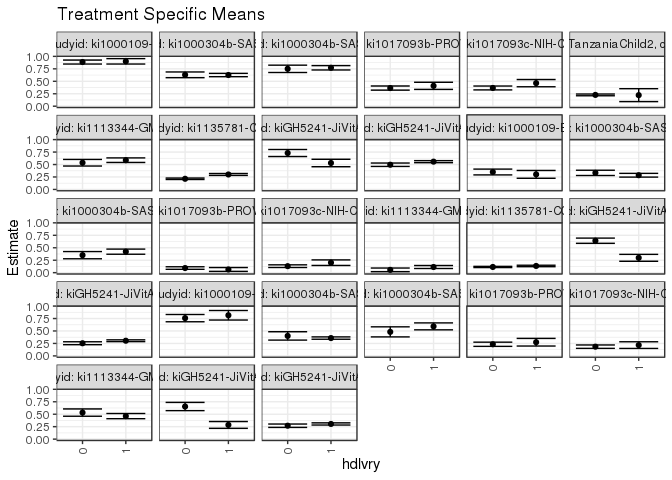

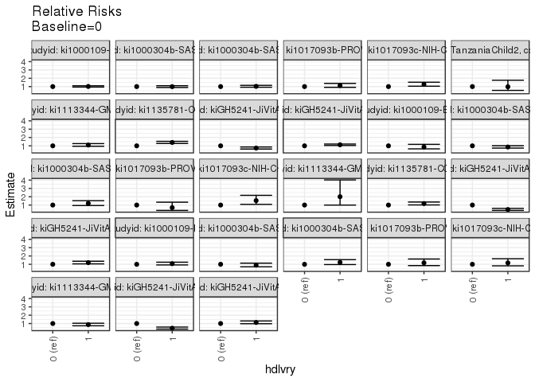

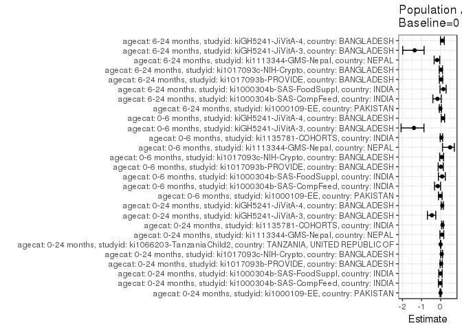

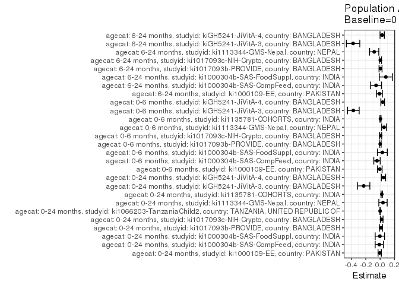

## Results Table

### Parameter: TSM

| agecat | studyid | country | intervention_level | baseline_level | estimate | ci_lower | ci_upper |
| --- | --- | --- | --- | --- | --- | --- | --- |
| 0-24 months | ki1000109-EE | PAKISTAN | 0 | NA | 0.8862520 | 0.8466776 | 0.9258263 |
| 0-24 months | ki1000109-EE | PAKISTAN | 1 | NA | 0.9005869 | 0.8464646 | 0.9547091 |
| 0-24 months | ki1000304b-SAS-CompFeed | INDIA | 0 | NA | 0.6300452 | 0.5727600 | 0.6873303 |
| 0-24 months | ki1000304b-SAS-CompFeed | INDIA | 1 | NA | 0.6256821 | 0.5925423 | 0.6588218 |
| 0-24 months | ki1000304b-SAS-FoodSuppl | INDIA | 0 | NA | 0.7502141 | 0.6767621 | 0.8236661 |
| 0-24 months | ki1000304b-SAS-FoodSuppl | INDIA | 1 | NA | 0.7710394 | 0.7272958 | 0.8147830 |
| 0-24 months | ki1017093b-PROVIDE | BANGLADESH | 0 | NA | 0.3641618 | 0.3227337 | 0.4055900 |
| 0-24 months | ki1017093b-PROVIDE | BANGLADESH | 1 | NA | 0.4088398 | 0.3371680 | 0.4805116 |
| 0-24 months | ki1017093c-NIH-Crypto | BANGLADESH | 0 | NA | 0.3661695 | 0.3275320 | 0.4048069 |
| 0-24 months | ki1017093c-NIH-Crypto | BANGLADESH | 1 | NA | 0.4628646 | 0.3903110 | 0.5354182 |
| 0-24 months | ki1066203-TanzaniaChild2 | TANZANIA, UNITED REPUBLIC OF | 0 | NA | 0.2270032 | 0.2096319 | 0.2443745 |
| 0-24 months | ki1066203-TanzaniaChild2 | TANZANIA, UNITED REPUBLIC OF | 1 | NA | 0.2219209 | 0.0922200 | 0.3516217 |
| 0-24 months | ki1113344-GMS-Nepal | NEPAL | 0 | NA | 0.5357261 | 0.4697331 | 0.6017191 |
| 0-24 months | ki1113344-GMS-Nepal | NEPAL | 1 | NA | 0.5868062 | 0.5410119 | 0.6326004 |
| 0-24 months | ki1135781-COHORTS | INDIA | 0 | NA | 0.2138081 | 0.1993866 | 0.2282295 |
| 0-24 months | ki1135781-COHORTS | INDIA | 1 | NA | 0.3001853 | 0.2810573 | 0.3193132 |
| 0-24 months | kiGH5241-JiVitA-3 | BANGLADESH | 0 | NA | 0.7310184 | 0.6603163 | 0.8017205 |
| 0-24 months | kiGH5241-JiVitA-3 | BANGLADESH | 1 | NA | 0.5305261 | 0.4556573 | 0.6053949 |
| 0-24 months | kiGH5241-JiVitA-4 | BANGLADESH | 0 | NA | 0.4957885 | 0.4614957 | 0.5300814 |
| 0-24 months | kiGH5241-JiVitA-4 | BANGLADESH | 1 | NA | 0.5577228 | 0.5373368 | 0.5781087 |
| 0-6 months | ki1000109-EE | PAKISTAN | 0 | NA | 0.3499521 | 0.2916891 | 0.4082151 |
| 0-6 months | ki1000109-EE | PAKISTAN | 1 | NA | 0.3025058 | 0.2243770 | 0.3806347 |
| 0-6 months | ki1000304b-SAS-CompFeed | INDIA | 0 | NA | 0.3327871 | 0.2799700 | 0.3856041 |
| 0-6 months | ki1000304b-SAS-CompFeed | INDIA | 1 | NA | 0.2854065 | 0.2479105 | 0.3229025 |
| 0-6 months | ki1000304b-SAS-FoodSuppl | INDIA | 0 | NA | 0.3512317 | 0.2786664 | 0.4237970 |
| 0-6 months | ki1000304b-SAS-FoodSuppl | INDIA | 1 | NA | 0.4215558 | 0.3700884 | 0.4730231 |
| 0-6 months | ki1017093b-PROVIDE | BANGLADESH | 0 | NA | 0.0929968 | 0.0677202 | 0.1182734 |
| 0-6 months | ki1017093b-PROVIDE | BANGLADESH | 1 | NA | 0.0642701 | 0.0253085 | 0.1032317 |
| 0-6 months | ki1017093c-NIH-Crypto | BANGLADESH | 0 | NA | 0.1306142 | 0.1036109 | 0.1576176 |
| 0-6 months | ki1017093c-NIH-Crypto | BANGLADESH | 1 | NA | 0.2003757 | 0.1446773 | 0.2560741 |
| 0-6 months | ki1113344-GMS-Nepal | NEPAL | 0 | NA | 0.0567091 | 0.0200110 | 0.0934073 |
| 0-6 months | ki1113344-GMS-Nepal | NEPAL | 1 | NA | 0.1135027 | 0.0836069 | 0.1433984 |
| 0-6 months | ki1135781-COHORTS | INDIA | 0 | NA | 0.1145766 | 0.1032368 | 0.1259163 |
| 0-6 months | ki1135781-COHORTS | INDIA | 1 | NA | 0.1347345 | 0.1200089 | 0.1494600 |
| 0-6 months | kiGH5241-JiVitA-3 | BANGLADESH | 0 | NA | 0.6410687 | 0.5885319 | 0.6936054 |
| 0-6 months | kiGH5241-JiVitA-3 | BANGLADESH | 1 | NA | 0.2981459 | 0.2286055 | 0.3676864 |
| 0-6 months | kiGH5241-JiVitA-4 | BANGLADESH | 0 | NA | 0.2539306 | 0.2246076 | 0.2832536 |
| 0-6 months | kiGH5241-JiVitA-4 | BANGLADESH | 1 | NA | 0.3044886 | 0.2865730 | 0.3224042 |
| 6-24 months | ki1000109-EE | PAKISTAN | 0 | NA | 0.7582170 | 0.6854374 | 0.8309966 |
| 6-24 months | ki1000109-EE | PAKISTAN | 1 | NA | 0.8154645 | 0.7202463 | 0.9106826 |
| 6-24 months | ki1000304b-SAS-CompFeed | INDIA | 0 | NA | 0.4009749 | 0.3168801 | 0.4850698 |
| 6-24 months | ki1000304b-SAS-CompFeed | INDIA | 1 | NA | 0.3578012 | 0.3345045 | 0.3810979 |
| 6-24 months | ki1000304b-SAS-FoodSuppl | INDIA | 0 | NA | 0.4821954 | 0.3808705 | 0.5835202 |
| 6-24 months | ki1000304b-SAS-FoodSuppl | INDIA | 1 | NA | 0.5929297 | 0.5231933 | 0.6626661 |
| 6-24 months | ki1017093b-PROVIDE | BANGLADESH | 0 | NA | 0.2337432 | 0.1914928 | 0.2759936 |
| 6-24 months | ki1017093b-PROVIDE | BANGLADESH | 1 | NA | 0.2743334 | 0.1975790 | 0.3510877 |
| 6-24 months | ki1017093c-NIH-Crypto | BANGLADESH | 0 | NA | 0.1855011 | 0.1513108 | 0.2196914 |
| 6-24 months | ki1017093c-NIH-Crypto | BANGLADESH | 1 | NA | 0.2166252 | 0.1498919 | 0.2833585 |
| 6-24 months | ki1113344-GMS-Nepal | NEPAL | 0 | NA | 0.5327065 | 0.4592602 | 0.6061528 |
| 6-24 months | ki1113344-GMS-Nepal | NEPAL | 1 | NA | 0.4621025 | 0.4100978 | 0.5141072 |
| 6-24 months | kiGH5241-JiVitA-3 | BANGLADESH | 0 | NA | 0.6545695 | 0.5718076 | 0.7373314 |
| 6-24 months | kiGH5241-JiVitA-3 | BANGLADESH | 1 | NA | 0.2851349 | 0.2169415 | 0.3533282 |
| 6-24 months | kiGH5241-JiVitA-4 | BANGLADESH | 0 | NA | 0.2695466 | 0.2356230 | 0.3034703 |
| 6-24 months | kiGH5241-JiVitA-4 | BANGLADESH | 1 | NA | 0.3046140 | 0.2829713 | 0.3262566 |

### Parameter: E(Y)

| agecat | studyid | country | intervention_level | baseline_level | estimate | ci_lower | ci_upper |
| --- | --- | --- | --- | --- | --- | --- | --- |
| 0-24 months | ki1000109-EE | PAKISTAN | NA | NA | 0.8806366 | 0.8478657 | 0.9134075 |
| 0-24 months | ki1000304b-SAS-CompFeed | INDIA | NA | NA | 0.6184000 | 0.5869018 | 0.6498982 |
| 0-24 months | ki1000304b-SAS-FoodSuppl | INDIA | NA | NA | 0.7464115 | 0.7046540 | 0.7881689 |
| 0-24 months | ki1017093b-PROVIDE | BANGLADESH | NA | NA | 0.3757143 | 0.3398113 | 0.4116172 |
| 0-24 months | ki1017093c-NIH-Crypto | BANGLADESH | NA | NA | 0.3878628 | 0.3531521 | 0.4225735 |
| 0-24 months | ki1066203-TanzaniaChild2 | TANZANIA, UNITED REPUBLIC OF | NA | NA | 0.2269129 | 0.2096946 | 0.2441313 |
| 0-24 months | ki1113344-GMS-Nepal | NEPAL | NA | NA | 0.5757576 | 0.5348239 | 0.6166913 |
| 0-24 months | ki1135781-COHORTS | INDIA | NA | NA | 0.2371053 | 0.2254305 | 0.2487802 |
| 0-24 months | kiGH5241-JiVitA-3 | BANGLADESH | NA | NA | 0.5014164 | 0.4307597 | 0.5720732 |
| 0-24 months | kiGH5241-JiVitA-4 | BANGLADESH | NA | NA | 0.5429904 | 0.5252738 | 0.5607071 |
| 0-6 months | ki1000109-EE | PAKISTAN | NA | NA | 0.3448276 | 0.2967843 | 0.3928709 |
| 0-6 months | ki1000304b-SAS-CompFeed | INDIA | NA | NA | 0.2892628 | 0.2523312 | 0.3261944 |
| 0-6 months | ki1000304b-SAS-FoodSuppl | INDIA | NA | NA | 0.3822115 | 0.3354600 | 0.4289631 |
| 0-6 months | ki1017093b-PROVIDE | BANGLADESH | NA | NA | 0.0942857 | 0.0726222 | 0.1159492 |
| 0-6 months | ki1017093c-NIH-Crypto | BANGLADESH | NA | NA | 0.1385224 | 0.1139141 | 0.1631308 |
| 0-6 months | ki1113344-GMS-Nepal | NEPAL | NA | NA | 0.1122995 | 0.0861492 | 0.1384497 |
| 0-6 months | ki1135781-COHORTS | INDIA | NA | NA | 0.1197098 | 0.1106766 | 0.1287430 |
| 0-6 months | kiGH5241-JiVitA-3 | BANGLADESH | NA | NA | 0.2670455 | 0.2046982 | 0.3293927 |
| 0-6 months | kiGH5241-JiVitA-4 | BANGLADESH | NA | NA | 0.2899487 | 0.2745556 | 0.3053419 |
| 6-24 months | ki1000109-EE | PAKISTAN | NA | NA | 0.7486631 | 0.6863237 | 0.8110026 |
| 6-24 months | ki1000304b-SAS-CompFeed | INDIA | NA | NA | 0.3441558 | 0.3190986 | 0.3692131 |
| 6-24 months | ki1000304b-SAS-FoodSuppl | INDIA | NA | NA | 0.5619469 | 0.4971181 | 0.6267757 |
| 6-24 months | ki1017093b-PROVIDE | BANGLADESH | NA | NA | 0.2394366 | 0.2018814 | 0.2769918 |
| 6-24 months | ki1017093c-NIH-Crypto | BANGLADESH | NA | NA | 0.1887097 | 0.1578857 | 0.2195336 |
| 6-24 months | ki1113344-GMS-Nepal | NEPAL | NA | NA | 0.4498886 | 0.4038220 | 0.4959553 |
| 6-24 months | kiGH5241-JiVitA-3 | BANGLADESH | NA | NA | 0.2771536 | 0.2152294 | 0.3390778 |
| 6-24 months | kiGH5241-JiVitA-4 | BANGLADESH | NA | NA | 0.2985158 | 0.2801281 | 0.3169036 |

### Parameter: RR

| agecat | studyid | country | intervention_level | baseline_level | estimate | ci_lower | ci_upper |
| --- | --- | --- | --- | --- | --- | --- | --- |
| 0-24 months | ki1000109-EE | PAKISTAN | 0 | 0 | 1.0000000 | 1.0000000 | 1.0000000 |
| 0-24 months | ki1000109-EE | PAKISTAN | 1 | 0 | 1.0161748 | 0.9427717 | 1.0952929 |
| 0-24 months | ki1000304b-SAS-CompFeed | INDIA | 0 | 0 | 1.0000000 | 1.0000000 | 1.0000000 |
| 0-24 months | ki1000304b-SAS-CompFeed | INDIA | 1 | 0 | 0.9930750 | 0.8910827 | 1.1067411 |
| 0-24 months | ki1000304b-SAS-FoodSuppl | INDIA | 0 | 0 | 1.0000000 | 1.0000000 | 1.0000000 |
| 0-24 months | ki1000304b-SAS-FoodSuppl | INDIA | 1 | 0 | 1.0277592 | 0.9193222 | 1.1489867 |
| 0-24 months | ki1017093b-PROVIDE | BANGLADESH | 0 | 0 | 1.0000000 | 1.0000000 | 1.0000000 |
| 0-24 months | ki1017093b-PROVIDE | BANGLADESH | 1 | 0 | 1.1226870 | 0.9109582 | 1.3836268 |
| 0-24 months | ki1017093c-NIH-Crypto | BANGLADESH | 0 | 0 | 1.0000000 | 1.0000000 | 1.0000000 |
| 0-24 months | ki1017093c-NIH-Crypto | BANGLADESH | 1 | 0 | 1.2640721 | 1.0478862 | 1.5248585 |
| 0-24 months | ki1066203-TanzaniaChild2 | TANZANIA, UNITED REPUBLIC OF | 0 | 0 | 1.0000000 | 1.0000000 | 1.0000000 |
| 0-24 months | ki1066203-TanzaniaChild2 | TANZANIA, UNITED REPUBLIC OF | 1 | 0 | 0.9776113 | 0.5422369 | 1.7625577 |
| 0-24 months | ki1113344-GMS-Nepal | NEPAL | 0 | 0 | 1.0000000 | 1.0000000 | 1.0000000 |
| 0-24 months | ki1113344-GMS-Nepal | NEPAL | 1 | 0 | 1.0953474 | 0.9466648 | 1.2673820 |
| 0-24 months | ki1135781-COHORTS | INDIA | 0 | 0 | 1.0000000 | 1.0000000 | 1.0000000 |
| 0-24 months | ki1135781-COHORTS | INDIA | 1 | 0 | 1.4039940 | 1.2801239 | 1.5398503 |
| 0-24 months | kiGH5241-JiVitA-3 | BANGLADESH | 0 | 0 | 1.0000000 | 1.0000000 | 1.0000000 |
| 0-24 months | kiGH5241-JiVitA-3 | BANGLADESH | 1 | 0 | 0.7257357 | 0.6130656 | 0.8591124 |
| 0-24 months | kiGH5241-JiVitA-4 | BANGLADESH | 0 | 0 | 1.0000000 | 1.0000000 | 1.0000000 |
| 0-24 months | kiGH5241-JiVitA-4 | BANGLADESH | 1 | 0 | 1.1249206 | 1.0397939 | 1.2170166 |
| 0-6 months | ki1000109-EE | PAKISTAN | 0 | 0 | 1.0000000 | 1.0000000 | 1.0000000 |
| 0-6 months | ki1000109-EE | PAKISTAN | 1 | 0 | 0.8644207 | 0.6350716 | 1.1765966 |
| 0-6 months | ki1000304b-SAS-CompFeed | INDIA | 0 | 0 | 1.0000000 | 1.0000000 | 1.0000000 |
| 0-6 months | ki1000304b-SAS-CompFeed | INDIA | 1 | 0 | 0.8576250 | 0.7282464 | 1.0099887 |
| 0-6 months | ki1000304b-SAS-FoodSuppl | INDIA | 0 | 0 | 1.0000000 | 1.0000000 | 1.0000000 |
| 0-6 months | ki1000304b-SAS-FoodSuppl | INDIA | 1 | 0 | 1.2002214 | 0.9434783 | 1.5268305 |
| 0-6 months | ki1017093b-PROVIDE | BANGLADESH | 0 | 0 | 1.0000000 | 1.0000000 | 1.0000000 |
| 0-6 months | ki1017093b-PROVIDE | BANGLADESH | 1 | 0 | 0.6910995 | 0.3555791 | 1.3432132 |
| 0-6 months | ki1017093c-NIH-Crypto | BANGLADESH | 0 | 0 | 1.0000000 | 1.0000000 | 1.0000000 |
| 0-6 months | ki1017093c-NIH-Crypto | BANGLADESH | 1 | 0 | 1.5341035 | 1.0846917 | 2.1697166 |
| 0-6 months | ki1113344-GMS-Nepal | NEPAL | 0 | 0 | 1.0000000 | 1.0000000 | 1.0000000 |
| 0-6 months | ki1113344-GMS-Nepal | NEPAL | 1 | 0 | 2.0014878 | 0.9966055 | 4.0195980 |
| 0-6 months | ki1135781-COHORTS | INDIA | 0 | 0 | 1.0000000 | 1.0000000 | 1.0000000 |
| 0-6 months | ki1135781-COHORTS | INDIA | 1 | 0 | 1.1759337 | 1.0150056 | 1.3623769 |
| 0-6 months | kiGH5241-JiVitA-3 | BANGLADESH | 0 | 0 | 1.0000000 | 1.0000000 | 1.0000000 |
| 0-6 months | kiGH5241-JiVitA-3 | BANGLADESH | 1 | 0 | 0.4650764 | 0.3588628 | 0.6027264 |
| 0-6 months | kiGH5241-JiVitA-4 | BANGLADESH | 0 | 0 | 1.0000000 | 1.0000000 | 1.0000000 |
| 0-6 months | kiGH5241-JiVitA-4 | BANGLADESH | 1 | 0 | 1.1991019 | 1.0519729 | 1.3668084 |
| 6-24 months | ki1000109-EE | PAKISTAN | 0 | 0 | 1.0000000 | 1.0000000 | 1.0000000 |
| 6-24 months | ki1000109-EE | PAKISTAN | 1 | 0 | 1.0755027 | 0.9239151 | 1.2519615 |
| 6-24 months | ki1000304b-SAS-CompFeed | INDIA | 0 | 0 | 1.0000000 | 1.0000000 | 1.0000000 |
| 6-24 months | ki1000304b-SAS-CompFeed | INDIA | 1 | 0 | 0.8923281 | 0.7000795 | 1.1373700 |
| 6-24 months | ki1000304b-SAS-FoodSuppl | INDIA | 0 | 0 | 1.0000000 | 1.0000000 | 1.0000000 |
| 6-24 months | ki1000304b-SAS-FoodSuppl | INDIA | 1 | 0 | 1.2296462 | 0.9688761 | 1.5606018 |
| 6-24 months | ki1017093b-PROVIDE | BANGLADESH | 0 | 0 | 1.0000000 | 1.0000000 | 1.0000000 |
| 6-24 months | ki1017093b-PROVIDE | BANGLADESH | 1 | 0 | 1.1736526 | 0.8433483 | 1.6333233 |
| 6-24 months | ki1017093c-NIH-Crypto | BANGLADESH | 0 | 0 | 1.0000000 | 1.0000000 | 1.0000000 |
| 6-24 months | ki1017093c-NIH-Crypto | BANGLADESH | 1 | 0 | 1.1677839 | 0.8160801 | 1.6710605 |
| 6-24 months | ki1113344-GMS-Nepal | NEPAL | 0 | 0 | 1.0000000 | 1.0000000 | 1.0000000 |
| 6-24 months | ki1113344-GMS-Nepal | NEPAL | 1 | 0 | 0.8674617 | 0.7266473 | 1.0355641 |
| 6-24 months | kiGH5241-JiVitA-3 | BANGLADESH | 0 | 0 | 1.0000000 | 1.0000000 | 1.0000000 |
| 6-24 months | kiGH5241-JiVitA-3 | BANGLADESH | 1 | 0 | 0.4356067 | 0.3289129 | 0.5769100 |
| 6-24 months | kiGH5241-JiVitA-4 | BANGLADESH | 0 | 0 | 1.0000000 | 1.0000000 | 1.0000000 |
| 6-24 months | kiGH5241-JiVitA-4 | BANGLADESH | 1 | 0 | 1.1300974 | 0.9771571 | 1.3069752 |

### Parameter: PAR

| agecat | studyid | country | intervention_level | baseline_level | estimate | ci_lower | ci_upper |
| --- | --- | --- | --- | --- | --- | --- | --- |
| 0-24 months | ki1000109-EE | PAKISTAN | 0 | NA | -0.0056153 | -0.0287137 | 0.0174830 |
| 0-24 months | ki1000304b-SAS-CompFeed | INDIA | 0 | NA | -0.0116452 | -0.0691365 | 0.0458461 |
| 0-24 months | ki1000304b-SAS-FoodSuppl | INDIA | 0 | NA | -0.0038026 | -0.0690007 | 0.0613955 |
| 0-24 months | ki1017093b-PROVIDE | BANGLADESH | 0 | NA | 0.0115524 | -0.0099021 | 0.0330070 |
| 0-24 months | ki1017093c-NIH-Crypto | BANGLADESH | 0 | NA | 0.0216933 | 0.0029795 | 0.0404072 |
| 0-24 months | ki1066203-TanzaniaChild2 | TANZANIA, UNITED REPUBLIC OF | 0 | NA | -0.0000903 | -0.0023924 | 0.0022119 |
| 0-24 months | ki1113344-GMS-Nepal | NEPAL | 0 | NA | 0.0400315 | -0.0182094 | 0.0982723 |
| 0-24 months | ki1135781-COHORTS | INDIA | 0 | NA | 0.0232972 | 0.0132911 | 0.0333034 |
| 0-24 months | kiGH5241-JiVitA-3 | BANGLADESH | 0 | NA | -0.2296020 | -0.3159249 | -0.1432791 |
| 0-24 months | kiGH5241-JiVitA-4 | BANGLADESH | 0 | NA | 0.0472019 | 0.0175325 | 0.0768713 |
| 0-6 months | ki1000109-EE | PAKISTAN | 0 | NA | -0.0051245 | -0.0380323 | 0.0277832 |
| 0-6 months | ki1000304b-SAS-CompFeed | INDIA | 0 | NA | -0.0435242 | -0.0879230 | 0.0008745 |
| 0-6 months | ki1000304b-SAS-FoodSuppl | INDIA | 0 | NA | 0.0309799 | -0.0383810 | 0.1003407 |
| 0-6 months | ki1017093b-PROVIDE | BANGLADESH | 0 | NA | 0.0012889 | -0.0112410 | 0.0138188 |
| 0-6 months | ki1017093c-NIH-Crypto | BANGLADESH | 0 | NA | 0.0079082 | -0.0061611 | 0.0219775 |
| 0-6 months | ki1113344-GMS-Nepal | NEPAL | 0 | NA | 0.0555903 | 0.0215250 | 0.0896556 |
| 0-6 months | ki1135781-COHORTS | INDIA | 0 | NA | 0.0051332 | -0.0024601 | 0.0127265 |
| 0-6 months | kiGH5241-JiVitA-3 | BANGLADESH | 0 | NA | -0.3740232 | -0.4553632 | -0.2926832 |
| 0-6 months | kiGH5241-JiVitA-4 | BANGLADESH | 0 | NA | 0.0360182 | 0.0102935 | 0.0617429 |
| 6-24 months | ki1000109-EE | PAKISTAN | 0 | NA | -0.0095539 | -0.0505633 | 0.0314555 |
| 6-24 months | ki1000304b-SAS-CompFeed | INDIA | 0 | NA | -0.0568191 | -0.1331779 | 0.0195397 |
| 6-24 months | ki1000304b-SAS-FoodSuppl | INDIA | 0 | NA | 0.0797515 | -0.0114799 | 0.1709830 |
| 6-24 months | ki1017093b-PROVIDE | BANGLADESH | 0 | NA | 0.0056934 | -0.0152770 | 0.0266637 |
| 6-24 months | ki1017093c-NIH-Crypto | BANGLADESH | 0 | NA | 0.0032086 | -0.0127426 | 0.0191597 |
| 6-24 months | ki1113344-GMS-Nepal | NEPAL | 0 | NA | -0.0828179 | -0.1468561 | -0.0187796 |
| 6-24 months | kiGH5241-JiVitA-3 | BANGLADESH | 0 | NA | -0.3774160 | -0.4710117 | -0.2838202 |
| 6-24 months | kiGH5241-JiVitA-4 | BANGLADESH | 0 | NA | 0.0289692 | -0.0009238 | 0.0588622 |

### Parameter: PAF

| agecat | studyid | country | intervention_level | baseline_level | estimate | ci_lower | ci_upper |
| --- | --- | --- | --- | --- | --- | --- | --- |
| 0-24 months | ki1000109-EE | PAKISTAN | 0 | NA | -0.0063765 | -0.0329581 | 0.0195212 |
| 0-24 months | ki1000304b-SAS-CompFeed | INDIA | 0 | NA | -0.0188311 | -0.1164723 | 0.0702708 |
| 0-24 months | ki1000304b-SAS-FoodSuppl | INDIA | 0 | NA | -0.0050945 | -0.0963860 | 0.0785955 |
| 0-24 months | ki1017093b-PROVIDE | BANGLADESH | 0 | NA | 0.0307479 | -0.0280845 | 0.0862136 |
| 0-24 months | ki1017093c-NIH-Crypto | BANGLADESH | 0 | NA | 0.0559305 | 0.0064066 | 0.1029859 |
| 0-24 months | ki1066203-TanzaniaChild2 | TANZANIA, UNITED REPUBLIC OF | 0 | NA | -0.0003977 | -0.0105949 | 0.0096966 |
| 0-24 months | ki1113344-GMS-Nepal | NEPAL | 0 | NA | 0.0695284 | -0.0366393 | 0.1648229 |
| 0-24 months | ki1135781-COHORTS | INDIA | 0 | NA | 0.0982569 | 0.0553804 | 0.1391873 |
| 0-24 months | kiGH5241-JiVitA-3 | BANGLADESH | 0 | NA | -0.4579068 | -0.6926172 | -0.2557430 |
| 0-24 months | kiGH5241-JiVitA-4 | BANGLADESH | 0 | NA | 0.0869295 | 0.0305946 | 0.1399907 |
| 0-6 months | ki1000109-EE | PAKISTAN | 0 | NA | -0.0148611 | -0.1149468 | 0.0762401 |
| 0-6 months | ki1000304b-SAS-CompFeed | INDIA | 0 | NA | -0.1504661 | -0.3196304 | -0.0029870 |
| 0-6 months | ki1000304b-SAS-FoodSuppl | INDIA | 0 | NA | 0.0810542 | -0.1166675 | 0.2437666 |
| 0-6 months | ki1017093b-PROVIDE | BANGLADESH | 0 | NA | 0.0136700 | -0.1287173 | 0.1380952 |
| 0-6 months | ki1017093c-NIH-Crypto | BANGLADESH | 0 | NA | 0.0570898 | -0.0494988 | 0.1528531 |
| 0-6 months | ki1113344-GMS-Nepal | NEPAL | 0 | NA | 0.4950186 | 0.0981095 | 0.7172536 |
| 0-6 months | ki1135781-COHORTS | INDIA | 0 | NA | 0.0428806 | -0.0225187 | 0.1040969 |
| 0-6 months | kiGH5241-JiVitA-3 | BANGLADESH | 0 | NA | -1.4005976 | -2.0734063 | -0.8750755 |
| 0-6 months | kiGH5241-JiVitA-4 | BANGLADESH | 0 | NA | 0.1242225 | 0.0309383 | 0.2085270 |
| 6-24 months | ki1000109-EE | PAKISTAN | 0 | NA | -0.0127613 | -0.0691169 | 0.0406236 |
| 6-24 months | ki1000304b-SAS-CompFeed | INDIA | 0 | NA | -0.1650969 | -0.4075601 | 0.0356001 |
| 6-24 months | ki1000304b-SAS-FoodSuppl | INDIA | 0 | NA | 0.1419201 | -0.0340062 | 0.2879142 |
| 6-24 months | ki1017093b-PROVIDE | BANGLADESH | 0 | NA | 0.0237782 | -0.0677711 | 0.1074783 |
| 6-24 months | ki1017093c-NIH-Crypto | BANGLADESH | 0 | NA | 0.0170026 | -0.0712060 | 0.0979476 |
| 6-24 months | ki1113344-GMS-Nepal | NEPAL | 0 | NA | -0.1840852 | -0.3396784 | -0.0465630 |
| 6-24 months | kiGH5241-JiVitA-3 | BANGLADESH | 0 | NA | -1.3617577 | -1.9878950 | -0.8668324 |
| 6-24 months | kiGH5241-JiVitA-4 | BANGLADESH | 0 | NA | 0.0970441 | -0.0085662 | 0.1915955 |